# Assignment 7

**Group D**

## Exercise 1

### 1.1 a)

#### i)

$ \sum _{j=1} p_{j|i} = 1 $

$ p_{j|i} = \frac{e^{-||x_i - x_j||^2 \ / \ 2 \sigma _i^2}}{\sum \limits_{k \neq i} e^{-||x_i - x_k||^2 \ / \ 2 \sigma _i^2}} $

$ 1 = \sum \limits_{j = 1} ^n \frac{e^{-||x_i - x_j||^2 \ / \ 2 \sigma _i^2}}{\sum \limits_{k \neq i} e^{-||x_i - x_k||^2 \ / \ 2 \sigma _i^2}} $ with example points $ \in \{1,2\}, \sigma = 1 $

$ 1 = \frac{e^{-1}}{e^{-1} + e^{-2}} + \frac{e^{-2}}{e^{-1} + e^{-2}} $

$ 1 = 1 $

#### ii)

There is a need to have a reference point at the beginning. This point is the closest one to the point of the distribution.

#### iii)

$\lim _{\sigma_9 \to \infty} = \begin{pmatrix} \frac{1}{12} \\ \frac{1}{12} \\ \frac{1}{12} \\ \frac{1}{12} \\ \frac{1}{12} \\ \frac{1}{12} \\ \frac{1}{12} \\ \frac{1}{12} \\ 0 \\ \frac{1}{12} \\ \frac{1}{12} \\ \frac{1}{12} \\ \frac{1}{12} \\ \end{pmatrix}$

#### iv)

This is the case, because of the different sum in the denominator for every distribution point.

### 1.1 b)

#### i)

| $Data \ point\ x_i$ | $ Scaling\ \sigma_i$ | $ Distribution\ P_i$ | $ Entropy\ H(P_i)$ | $Perplexity\ Perp(P_1)$ | $ Curve $ |
| --- | --- | --- | --- | --- | --- |
| $x_4$ | $0.34$ | $D$ | $0.993761$ | $1.99137$ | $ A $ |
| $c_2$ | $0.18$ | $C$ | $0.988433$ | $1.98403$ | $B$ |

#### ii)

There is a plateau, because no new points will be added at around $ \sigma_i \in \[0.5,1.5\]$. The blue line reaches this plateau before the orange line, because the points from the orange line are closer to the reference point than from the blue dataset.

#### iii)

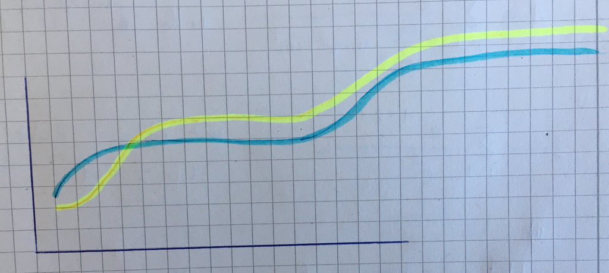

### 1.1 c)

$ 1 = \sum \limits_{i = 1} ^n \sum \limits_{j = 1} ^n p_{ij} $

$1 = \sum \limits_{i = 1} ^n \sum \limits_{j = 1} ^n \frac{p_{ij} + p_{ji}}{2n} $ with Points $x_1 \&\ x_2$ and $p_{12} = 1,p_{21} = 1 $

$ 1 = \frac{1 +1}{4} + \frac{1 + 1}{4} = \frac{4}{4} $

## 1.2

### 1.2 a)

[output not shown]

### 1.2 b)

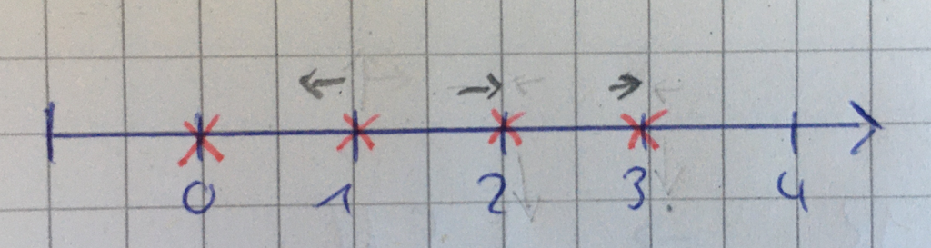

### 1.2 c)

$ \frac{- \delta D_Q(P)}{\delta y_1} = 4 \sum \limits_{j = 1} ^n (p_{ij} - q_{ij})(y_i - y_j)(1 + ||y_i - y_j||^2)^{-1}$

### 1.2 d)

Color groups are formed which describe the affiliations of the points to each other. These color groups are the clusters. The corresponding points can be determined by a row within the cluster.

## 1.3

### 1.3 a)

[output not shown]

### 1.3 b)

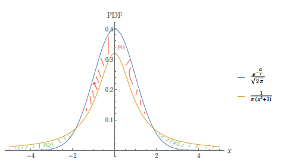

### 1.3 c)

Die Punkte können besser verteilt werden, da mehr Platz zur x-Achse ist.

### 1.3 d)

Projection A maps to algorithm SNE and projection B maps to algorithm t-SNE, due to the concentration of data points.